# Project: Investigate a Dataset - [No - Show Appointments]

- Introduction
- Data Wrangling
- Exploratory Data Analysis
- Conclusions

# Introduction

### Dataset Description

> This dataset contains the information from over 110k medical appointments in Brazil, and its associated with 14 variables. The most important of these variables if that which tells if the patient show-up or no show to the appointment. Therefore, it is neccessary to know why someone makes a doctor appointment, recieves all the instructions and no-show.

> **Below are the list of all columns name and what they signify in the dataset**

> **PatientId**: Identification of patient.

> **AppointmentID**: Identification of eacch appointment.

> **Gender**: Male or Female.

> **Age**: How old is the patient.

> **Neighbourhood**: Where the appointments takes place.

> **Scholarship**: True or False

> **Hipertension**: True or False

> **Diabetes**: True or False

> **Alcoholism**: True or False

> **Handcap**: True or False

> **SMS_recieved**: 1 or more messages sent to the patient.

> **No-show**: Yes or No

### Question(s) for Analysis

> **1.)**: What is the proportion and of the patients in dataset Showed up and Didn't show for their appointment?

> **2.)**: Which Age Category has the highest number of patients among the patient that showed up and those that didn't show up for the appointment

> **3.)**: What is the Age relationship between the patient that showed and those that didn't show up?

> **4.)**: What is the gender distribution of all patient in the dataset?

> **5.)**: Which ailment record has the highest number of patient Showed up and the lowest number of patients Show up?

> **6.)**: What age group has the Highest and lowest number of patient that showed and did not show?

> **7.)**: How does Date difference affect patient from Showing up for their appointment?

> **8.)**: What effect does SMS recieved by patients have on showing up or not showing up for thier appointment?

```python
# Use this cell to set up import statements for all of the packages that you
#   plan to use.

# Remember to include a 'magic word' so that your visualizations are plotted
#   inline with the notebook. See this page for more:
#   http://ipython.readthedocs.io/en/stable/interactive/magics.html

import pandas as pd
import numpy as np
import matplotlib.pyplot as plt
import seaborn as sns
% matplotlib inline
```

```python
# Defining percentage function.
def func_percent(a,b):
    print (a/b* 100)
```

# Data Wrangling

## General Properties

```python
# Load your data and print out a few lines. Perform operations to inspect data
# types and look for instances of missing or possibly errant data.
df=pd.read_csv('No_SA.csv')
df.head()
```

|  | PatientId | AppointmentID | Gender | ScheduledDay | AppointmentDay | Age | Neighbourhood | Scholarship | Hipertension | Diabetes | Alcoholism | Handcap | SMS_received | No-show |
| --- | --- | --- | --- | --- | --- | --- | --- | --- | --- | --- | --- | --- | --- | --- |
| 0 | 2.987250e+13 | 5642903 | F | 2016-04-29T18:38:08Z | 2016-04-29T00:00:00Z | 62 | JARDIM DA PENHA | 0 | 1 | 0 | 0 | 0 | 0 | No |
| 1 | 5.589978e+14 | 5642503 | M | 2016-04-29T16:08:27Z | 2016-04-29T00:00:00Z | 56 | JARDIM DA PENHA | 0 | 0 | 0 | 0 | 0 | 0 | No |
| 2 | 4.262962e+12 | 5642549 | F | 2016-04-29T16:19:04Z | 2016-04-29T00:00:00Z | 62 | MATA DA PRAIA | 0 | 0 | 0 | 0 | 0 | 0 | No |
| 3 | 8.679512e+11 | 5642828 | F | 2016-04-29T17:29:31Z | 2016-04-29T00:00:00Z | 8 | PONTAL DE CAMBURI | 0 | 0 | 0 | 0 | 0 | 0 | No |
| 4 | 8.841186e+12 | 5642494 | F | 2016-04-29T16:07:23Z | 2016-04-29T00:00:00Z | 56 | JARDIM DA PENHA | 0 | 1 | 1 | 0 | 0 | 0 | No |

The properties of each column for the dataset(No_SA) must be checked before performing any Data cleaning

```python
# this returns the general info of this dataset
df.info()
```

```
<class 'pandas.core.frame.DataFrame'>
RangeIndex: 110527 entries, 0 to 110526
Data columns (total 14 columns):
PatientId         110527 non-null float64
AppointmentID     110527 non-null int64
Gender            110527 non-null object
ScheduledDay      110527 non-null object
AppointmentDay    110527 non-null object
Age               110527 non-null int64
Neighbourhood     110527 non-null object
Scholarship       110527 non-null int64
Hipertension      110527 non-null int64
Diabetes          110527 non-null int64
Alcoholism        110527 non-null int64
Handcap           110527 non-null int64
SMS_received      110527 non-null int64
No-show           110527 non-null object
dtypes: float64(1), int64(8), object(5)
memory usage: 11.8+ MB
```

```python
# this is to return the data types of each columns
df.dtypes
```

```
PatientId         float64
AppointmentID       int64
Gender             object
ScheduledDay       object
AppointmentDay     object
Age                 int64
Neighbourhood      object
Scholarship         int64
Hipertension        int64
Diabetes            int64
Alcoholism          int64
Handcap             int64
SMS_received        int64
No-show            object
dtype: object
```

```python
# this is to return the a tuples of the dimension of the dataset
df.shape
```

```
(110527, 14)
```

```python
# this to return the unique values in each column
df.nunique()
```

```
PatientId          62299
AppointmentID     110527
Gender                 2
ScheduledDay      103549
AppointmentDay        27
Age                  104
Neighbourhood         81
Scholarship            2
Hipertension           2
Diabetes               2
Alcoholism             2
Handcap                5
SMS_received           2
No-show                2
dtype: int64
```

```python
# this to return the number of duplicated rows in the dataset.
df.duplicated().sum()
```

```
0
```

```python
# this is to return useful discriptive statistics for each column
df.describe()
```

|  | PatientId | AppointmentID | Age | Scholarship | Hipertension | Diabetes | Alcoholism | Handcap | SMS_received |
| --- | --- | --- | --- | --- | --- | --- | --- | --- | --- |
| count | 1.105270e+05 | 1.105270e+05 | 110527.000000 | 110527.000000 | 110527.000000 | 110527.000000 | 110527.000000 | 110527.000000 | 110527.000000 |
| mean | 1.474963e+14 | 5.675305e+06 | 37.088874 | 0.098266 | 0.197246 | 0.071865 | 0.030400 | 0.022248 | 0.321026 |
| std | 2.560949e+14 | 7.129575e+04 | 23.110205 | 0.297675 | 0.397921 | 0.258265 | 0.171686 | 0.161543 | 0.466873 |
| min | 3.921784e+04 | 5.030230e+06 | -1.000000 | 0.000000 | 0.000000 | 0.000000 | 0.000000 | 0.000000 | 0.000000 |
| 25% | 4.172614e+12 | 5.640286e+06 | 18.000000 | 0.000000 | 0.000000 | 0.000000 | 0.000000 | 0.000000 | 0.000000 |
| 50% | 3.173184e+13 | 5.680573e+06 | 37.000000 | 0.000000 | 0.000000 | 0.000000 | 0.000000 | 0.000000 | 0.000000 |
| 75% | 9.439172e+13 | 5.725524e+06 | 55.000000 | 0.000000 | 0.000000 | 0.000000 | 0.000000 | 0.000000 | 1.000000 |
| max | 9.999816e+14 | 5.790484e+06 | 115.000000 | 1.000000 | 1.000000 | 1.000000 | 1.000000 | 4.000000 | 1.000000 |

```python
# this is to check for null values in the data set.
df.isnull().sum()
```

```
PatientId         0
AppointmentID     0
Gender            0
ScheduledDay      0
AppointmentDay    0
Age               0
Neighbourhood     0
Scholarship       0
Hipertension      0
Diabetes          0
Alcoholism        0
Handcap           0
SMS_received      0
No-show           0
dtype: int64
```

### Data Cleaning

> Having checked the general properties of the dataset, it was observed that some of the column's datatype such as "PatientId" which is a "float" needs to be changed to integers,"Appointment" and "ScheduleDay" needs be change to date time. Also some renaming of "No-show", "Handcap","AppointmentID","PatientId","Hipertension","ScheduledDay"and"AppointmentDay" column. Lastly, correcting of data input into the handicap column needs to be addressed since the "describe" function returns "Handcap" maximum value to be 4. Row with negative age and Scholarship column will dropped before any form of further analysis can be done on this dataset. This process is called data cleaning processes

### Incorrect Datatypes

```python
# After discussing the structure of the data and any problems that need to be
#   cleaned, perform those cleaning steps in the second part of this section.

# This is to return the PatientId(column) which has a datatype(float) to integers
df['PatientId']=df['PatientId'].astype(int)
```

```python
# This is to remove timestep in AppointmentDay and ScheduledDay Column
df['AppointmentDay']=df['AppointmentDay'].apply(lambda x: x.split("T")[0])
df['ScheduledDay']=df['ScheduledDay'].apply(lambda x: x.split("T")[0])
```

```python
# This is to view the effect of the code above.
df.head(1)
```

|  | PatientId | AppointmentID | Gender | ScheduledDay | AppointmentDay | Age | Neighbourhood | Scholarship | Hipertension | Diabetes | Alcoholism | Handcap | SMS_received | No-show |
| --- | --- | --- | --- | --- | --- | --- | --- | --- | --- | --- | --- | --- | --- | --- |
| 0 | 29872499824296 | 5642903 | F | 2016-04-29 | 2016-04-29 | 62 | JARDIM DA PENHA | 0 | 1 | 0 | 0 | 0 | 0 | No |

```python
# This is to change the data type for both AppointmentDay and ScheduledDay Column to datetime
df['AppointmentDay'] = pd.to_datetime(df['AppointmentDay'])
df['ScheduledDay'] = pd.to_datetime(df['ScheduledDay'])
```

```python
# this is to check the effect of the change in data type of both AppointmentDay and ScheduledDay Column
df.info()
```

```
<class 'pandas.core.frame.DataFrame'>
RangeIndex: 110527 entries, 0 to 110526
Data columns (total 14 columns):
PatientId         110527 non-null int64
AppointmentID     110527 non-null int64
Gender            110527 non-null object
ScheduledDay      110527 non-null datetime64[ns]
AppointmentDay    110527 non-null datetime64[ns]
Age               110527 non-null int64
Neighbourhood     110527 non-null object
Scholarship       110527 non-null int64
Hipertension      110527 non-null int64
Diabetes          110527 non-null int64
Alcoholism        110527 non-null int64
Handcap           110527 non-null int64
SMS_received      110527 non-null int64
No-show           110527 non-null object
dtypes: datetime64[ns](2), int64(9), object(3)
memory usage: 11.8+ MB
```

## Rename of Column

```python
 # this to rename the name of the column "No-show" to "No_show", "Hipertension" to Hypertension, "Handcap" to Handicap, "PatientId" to Patient_Id, "ScheduledDay" to Scheduled_Day,"AppointmentDay" to Appointment_Day, "AppointmentID" to Appointment_ID.
df.rename(columns={'No-show':'No_show', 'Hipertension':'Hypertension','Handcap':'Handicap','PatientId':'Patient_Id','ScheduledDay':'Scheduled_Day','AppointmentDay':'Appointment_Day','AppointmentID':'Appointment_ID'}, inplace=True)
```

```python
# To check if the change has effect on the data set.
df.head(1)
```

|  | Patient_Id | Appointment_ID | Gender | Scheduled_Day | Appointment_Day | Age | Neighbourhood | Scholarship | Hypertension | Diabetes | Alcoholism | Handicap | SMS_received | No_show |
| --- | --- | --- | --- | --- | --- | --- | --- | --- | --- | --- | --- | --- | --- | --- |
| 0 | 29872499824296 | 5642903 | F | 2016-04-29 | 2016-04-29 | 62 | JARDIM DA PENHA | 0 | 1 | 0 | 0 | 0 | 0 | No |

## Correcting Wrong Inputed Values

> It was observed that the "Handcap" column have some values which are greater than 1, but from the dataset directory the significance of the column is either TRUE or FALSE. Going by this directory its can be said that True is being represented by 1 while False is represented by 0. Therefore every values in the handicap column greater than one (> 1) will be replaced by 1.

```python
# This is to replace values greater than 1 in the handicap column.
df['Handicap'].replace({2:1,3:1,4:1}, inplace=True)
```

```python
# Let check the unique values in the handicap
df.nunique()
```

```
Patient_Id          62299
Appointment_ID     110527
Gender                  2
Scheduled_Day         111
Appointment_Day        27
Age                   104
Neighbourhood          81
Scholarship             2
Hypertension            2
Diabetes                2
Alcoholism              2
Handicap                2
SMS_received            2
No_show                 2
dtype: int64
```

## Dropping of Rows and Column

> Dropping of row is needed because when the "describe" function was used, it was obsevered that the minimum value of Age is -1, which is impossible to have a negative value for Age. Also, the scholership column will be dropped because it will not be required for this analysis.

```python
# This is to view the rows that has an Age less than 0
df[df.Age< 0]
```

|  | Patient_Id | Appointment_ID | Gender | Scheduled_Day | Appointment_Day | Age | Neighbourhood | Scholarship | Hypertension | Diabetes | Alcoholism | Handicap | SMS_received | No_show |
| --- | --- | --- | --- | --- | --- | --- | --- | --- | --- | --- | --- | --- | --- | --- |
| 99832 | 465943158731293 | 5775010 | F | 2016-06-06 | 2016-06-06 | -1 | ROMÃO | 0 | 0 | 0 | 0 | 0 | 0 | No |

```python
# Now we are dropping the row
df.drop(df[df['Age']<0].index,inplace=True)
```

```python
# This to see if the row has been dropped.
df[df.Age< 0]
```

|  | Patient_Id | Appointment_ID | Gender | Scheduled_Day | Appointment_Day | Age | Neighbourhood | Scholarship | Hypertension | Diabetes | Alcoholism | Handicap | SMS_received | No_show |
| --- | --- | --- | --- | --- | --- | --- | --- | --- | --- | --- | --- | --- | --- | --- |

```python
# Dropping of Scholarship
df.drop(['Scholarship'],axis=1, inplace=True)
```

```python
# To cross check if the column has been dropped.
df.head(1)
```

|  | Patient_Id | Appointment_ID | Gender | Scheduled_Day | Appointment_Day | Age | Neighbourhood | Hypertension | Diabetes | Alcoholism | Handicap | SMS_received | No_show |
| --- | --- | --- | --- | --- | --- | --- | --- | --- | --- | --- | --- | --- | --- |
| 0 | 29872499824296 | 5642903 | F | 2016-04-29 | 2016-04-29 | 62 | JARDIM DA PENHA | 1 | 0 | 0 | 0 | 0 | No |

## Simplifying the No_show Column

> The no show column seems a little confusing and it could leads to miss-interpretation of answer whether a patient shows up or not. From the dataset directory it was said to be either True or False but it was observed that in this column the "NO" value means the patient show-up while "YES" value means the patient didnt show up, this seems confusing. Therefore, for easy understanding of this variable there will be need to a amend the No_show column to answer direct Yes or No.

```python
# This is to rename No_show to Showed
df.rename({"No_show":"Showed"}, axis=1, inplace= True)
# The negative "No" has to change to "Yes" while the Positive"Yes" has to be negative to match the column "Showed"
df["Showed"]=np.where(df["Showed"]== "No","Yes","No")
```

```python
# This change has to beconfirmed.
df.head()
```

|  | Patient_Id | Appointment_ID | Gender | Scheduled_Day | Appointment_Day | Age | Neighbourhood | Hypertension | Diabetes | Alcoholism | Handicap | SMS_received | Showed |
| --- | --- | --- | --- | --- | --- | --- | --- | --- | --- | --- | --- | --- | --- |
| 0 | 29872499824296 | 5642903 | F | 2016-04-29 | 2016-04-29 | 62 | JARDIM DA PENHA | 1 | 0 | 0 | 0 | 0 | Yes |
| 1 | 558997776694438 | 5642503 | M | 2016-04-29 | 2016-04-29 | 56 | JARDIM DA PENHA | 0 | 0 | 0 | 0 | 0 | Yes |
| 2 | 4262962299951 | 5642549 | F | 2016-04-29 | 2016-04-29 | 62 | MATA DA PRAIA | 0 | 0 | 0 | 0 | 0 | Yes |
| 3 | 867951213174 | 5642828 | F | 2016-04-29 | 2016-04-29 | 8 | PONTAL DE CAMBURI | 0 | 0 | 0 | 0 | 0 | Yes |
| 4 | 8841186448183 | 5642494 | F | 2016-04-29 | 2016-04-29 | 56 | JARDIM DA PENHA | 1 | 1 | 0 | 0 | 0 | Yes |

## Addition of More Features

> Some column are need to be added to be able to explore this dataset and this columns will be created from the existing columns. The purpose of this is to **compute statistics** and **create visualizations** for research questions. These columns includes;
> - Age Category as (Age_Cat) form Age column
> - Number of Showed as (Num_Showed) from Showed column
> - Date difference as (Date_diff) from the difference between appointment_Day and scheduled_Day column

```python
# Creating Age Category Column (Age_Cat)
bins=[0,16,35,65,115]
label = ["Children(0-16)","Youth(17-35)","Adult(36-65)","Elders(66-115)"]
df['Age_Cat'] = pd.cut(df['Age'],bins, labels=label)
# Creating Mumber of Showed (Num_Showed)
df['Num_Showed'] = np.where(df["Showed"] == "Yes",1,0)
# Creating Date difference (Date_diff)
df['Date_diff'] = df['Appointment_Day'] - df['Scheduled_Day']
```

```python
# check for change that was created
df.head()
```

|  | Patient_Id | Appointment_ID | Gender | Scheduled_Day | Appointment_Day | Age | Neighbourhood | Hypertension | Diabetes | Alcoholism | Handicap | SMS_received | Showed | Age_Cat | Num_Showed | Date_diff |
| --- | --- | --- | --- | --- | --- | --- | --- | --- | --- | --- | --- | --- | --- | --- | --- | --- |
| 0 | 29872499824296 | 5642903 | F | 2016-04-29 | 2016-04-29 | 62 | JARDIM DA PENHA | 1 | 0 | 0 | 0 | 0 | Yes | Adult(36-65) | 1 | 0 days |
| 1 | 558997776694438 | 5642503 | M | 2016-04-29 | 2016-04-29 | 56 | JARDIM DA PENHA | 0 | 0 | 0 | 0 | 0 | Yes | Adult(36-65) | 1 | 0 days |
| 2 | 4262962299951 | 5642549 | F | 2016-04-29 | 2016-04-29 | 62 | MATA DA PRAIA | 0 | 0 | 0 | 0 | 0 | Yes | Adult(36-65) | 1 | 0 days |
| 3 | 867951213174 | 5642828 | F | 2016-04-29 | 2016-04-29 | 8 | PONTAL DE CAMBURI | 0 | 0 | 0 | 0 | 0 | Yes | Children(0-16) | 1 | 0 days |
| 4 | 8841186448183 | 5642494 | F | 2016-04-29 | 2016-04-29 | 56 | JARDIM DA PENHA | 1 | 1 | 0 | 0 | 0 | Yes | Adult(36-65) | 1 | 0 days |

```python
# Now let's uses describe for the statistical properties of the dataset
df.describe()
```

|  | Patient_Id | Appointment_ID | Age | Hypertension | Diabetes | Alcoholism | Handicap | SMS_received | Num_Showed | Date_diff |
| --- | --- | --- | --- | --- | --- | --- | --- | --- | --- | --- |
| count | 1.105260e+05 | 1.105260e+05 | 110526.000000 | 110526.000000 | 110526.000000 | 110526.000000 | 110526.000000 | 110526.000000 | 110526.000000 | 110526 |
| mean | 1.474934e+14 | 5.675304e+06 | 37.089219 | 0.197248 | 0.071865 | 0.030400 | 0.020276 | 0.321029 | 0.798066 | 10 days 04:24:39.789370 |
| std | 2.560943e+14 | 7.129544e+04 | 23.110026 | 0.397923 | 0.258266 | 0.171686 | 0.140943 | 0.466874 | 0.401445 | 15 days 06:07:14.979140 |
| min | 3.921700e+04 | 5.030230e+06 | 0.000000 | 0.000000 | 0.000000 | 0.000000 | 0.000000 | 0.000000 | 0.000000 | -6 days +00:00:00 |
| 25% | 4.172536e+12 | 5.640285e+06 | 18.000000 | 0.000000 | 0.000000 | 0.000000 | 0.000000 | 0.000000 | 1.000000 | 0 days 00:00:00 |
| 50% | 3.173184e+13 | 5.680572e+06 | 37.000000 | 0.000000 | 0.000000 | 0.000000 | 0.000000 | 0.000000 | 1.000000 | 4 days 00:00:00 |
| 75% | 9.438963e+13 | 5.725523e+06 | 55.000000 | 0.000000 | 0.000000 | 0.000000 | 0.000000 | 1.000000 | 1.000000 | 15 days 00:00:00 |
| max | 9.999816e+14 | 5.790484e+06 | 115.000000 | 1.000000 | 1.000000 | 1.000000 | 1.000000 | 1.000000 | 1.000000 | 179 days 00:00:00 |

```python
# this is to discover the number of patient affected by the backdating.
No_of_rows_affected,_ = df[df["Date_diff"] < pd.Timedelta(1,'s')].shape # it can be assumed that the date backdate is by (1second)
No_of_rows_affected
```

```
38567
```

```python
# this returns the number patient that are affected but still showed up
showed_and_affected = df[df["Date_diff"] < pd.Timedelta(1,'s')]['Num_Showed'].sum()
showed_and_affected
```

```
36770
```

> The affected number of rows is 38567 and this is a significant number of the total rows and more importantly higher number of these affected patient showed up for their appointment. Therefore, the rows can not be dropped.

```python
# all rows with negative value will can be concidered zero by creating standard error dataframe
df.loc[df.Date_diff < pd.Timedelta(1,'s'),'Date_diff'] = pd.Timedelta(0,'s')
```

```python
# statistical check for Dated difference with negative (i.e backdated)
df.describe()
```

|  | Patient_Id | Appointment_ID | Age | Hypertension | Diabetes | Alcoholism | Handicap | SMS_received | Num_Showed | Date_diff |
| --- | --- | --- | --- | --- | --- | --- | --- | --- | --- | --- |
| count | 1.105260e+05 | 1.105260e+05 | 110526.000000 | 110526.000000 | 110526.000000 | 110526.000000 | 110526.000000 | 110526.000000 | 110526.000000 | 110526 |
| mean | 1.474934e+14 | 5.675304e+06 | 37.089219 | 0.197248 | 0.071865 | 0.030400 | 0.020276 | 0.321029 | 0.798066 | 10 days 04:24:47.606536 |
| std | 2.560943e+14 | 7.129544e+04 | 23.110026 | 0.397923 | 0.258266 | 0.171686 | 0.140943 | 0.466874 | 0.401445 | 15 days 06:07:08.735682 |
| min | 3.921700e+04 | 5.030230e+06 | 0.000000 | 0.000000 | 0.000000 | 0.000000 | 0.000000 | 0.000000 | 0.000000 | 0 days 00:00:00 |
| 25% | 4.172536e+12 | 5.640285e+06 | 18.000000 | 0.000000 | 0.000000 | 0.000000 | 0.000000 | 0.000000 | 1.000000 | 0 days 00:00:00 |
| 50% | 3.173184e+13 | 5.680572e+06 | 37.000000 | 0.000000 | 0.000000 | 0.000000 | 0.000000 | 0.000000 | 1.000000 | 4 days 00:00:00 |
| 75% | 9.438963e+13 | 5.725523e+06 | 55.000000 | 0.000000 | 0.000000 | 0.000000 | 0.000000 | 1.000000 | 1.000000 | 15 days 00:00:00 |
| max | 9.999816e+14 | 5.790484e+06 | 115.000000 | 1.000000 | 1.000000 | 1.000000 | 1.000000 | 1.000000 | 1.000000 | 179 days 00:00:00 |

```python
# creating Date difference category (Date_diff_Cat)
bins=[pd.Timedelta(-1,'d'),pd.Timedelta(3,'d'),pd.Timedelta(7,'d'),pd.Timedelta(14,'d'),pd.Timedelta(178,'d')]
label=["0-3Days","3-7Days","1_week","Over_a_month"]
df['Date_diff_Cat'] = pd.cut(df['Date_diff'],bins, labels=label)
```

```python
# This is to confirm that the new column has been impemented
df.head()
```

|  | Patient_Id | Appointment_ID | Gender | Scheduled_Day | Appointment_Day | Age | Neighbourhood | Hypertension | Diabetes | Alcoholism | Handicap | SMS_received | Showed | Age_Cat | Num_Showed | Date_diff | Date_diff_Cat |
| --- | --- | --- | --- | --- | --- | --- | --- | --- | --- | --- | --- | --- | --- | --- | --- | --- | --- |
| 0 | 29872499824296 | 5642903 | F | 2016-04-29 | 2016-04-29 | 62 | JARDIM DA PENHA | 1 | 0 | 0 | 0 | 0 | Yes | Adult(36-65) | 1 | 0 days | 0-3Days |
| 1 | 558997776694438 | 5642503 | M | 2016-04-29 | 2016-04-29 | 56 | JARDIM DA PENHA | 0 | 0 | 0 | 0 | 0 | Yes | Adult(36-65) | 1 | 0 days | 0-3Days |
| 2 | 4262962299951 | 5642549 | F | 2016-04-29 | 2016-04-29 | 62 | MATA DA PRAIA | 0 | 0 | 0 | 0 | 0 | Yes | Adult(36-65) | 1 | 0 days | 0-3Days |
| 3 | 867951213174 | 5642828 | F | 2016-04-29 | 2016-04-29 | 8 | PONTAL DE CAMBURI | 0 | 0 | 0 | 0 | 0 | Yes | Children(0-16) | 1 | 0 days | 0-3Days |
| 4 | 8841186448183 | 5642494 | F | 2016-04-29 | 2016-04-29 | 56 | JARDIM DA PENHA | 1 | 1 | 0 | 0 | 0 | Yes | Adult(36-65) | 1 | 0 days | 0-3Days |

## Exploratory Data Analysis

### 1.): What is the proportion and of the patients in dataset Showed up and Didn't show for their appointment?

```python
# To return the first five rows of the data set
df.head()
```

|  | Patient_Id | Appointment_ID | Gender | Scheduled_Day | Appointment_Day | Age | Neighbourhood | Hypertension | Diabetes | Alcoholism | Handicap | SMS_received | Showed | Age_Cat | Num_Showed | Date_diff | Date_diff_Cat |
| --- | --- | --- | --- | --- | --- | --- | --- | --- | --- | --- | --- | --- | --- | --- | --- | --- | --- |
| 0 | 29872499824296 | 5642903 | F | 2016-04-29 | 2016-04-29 | 62 | JARDIM DA PENHA | 1 | 0 | 0 | 0 | 0 | Yes | Adult(36-65) | 1 | 0 days | 0-3Days |
| 1 | 558997776694438 | 5642503 | M | 2016-04-29 | 2016-04-29 | 56 | JARDIM DA PENHA | 0 | 0 | 0 | 0 | 0 | Yes | Adult(36-65) | 1 | 0 days | 0-3Days |
| 2 | 4262962299951 | 5642549 | F | 2016-04-29 | 2016-04-29 | 62 | MATA DA PRAIA | 0 | 0 | 0 | 0 | 0 | Yes | Adult(36-65) | 1 | 0 days | 0-3Days |
| 3 | 867951213174 | 5642828 | F | 2016-04-29 | 2016-04-29 | 8 | PONTAL DE CAMBURI | 0 | 0 | 0 | 0 | 0 | Yes | Children(0-16) | 1 | 0 days | 0-3Days |
| 4 | 8841186448183 | 5642494 | F | 2016-04-29 | 2016-04-29 | 56 | JARDIM DA PENHA | 1 | 1 | 0 | 0 | 0 | Yes | Adult(36-65) | 1 | 0 days | 0-3Days |

```python
df.describe()
```

|  | Patient_Id | Appointment_ID | Age | Hypertension | Diabetes | Alcoholism | Handicap | SMS_received | Num_Showed | Date_diff |
| --- | --- | --- | --- | --- | --- | --- | --- | --- | --- | --- |
| count | 1.105260e+05 | 1.105260e+05 | 110526.000000 | 110526.000000 | 110526.000000 | 110526.000000 | 110526.000000 | 110526.000000 | 110526.000000 | 110526 |
| mean | 1.474934e+14 | 5.675304e+06 | 37.089219 | 0.197248 | 0.071865 | 0.030400 | 0.020276 | 0.321029 | 0.798066 | 10 days 04:24:47.606536 |
| std | 2.560943e+14 | 7.129544e+04 | 23.110026 | 0.397923 | 0.258266 | 0.171686 | 0.140943 | 0.466874 | 0.401445 | 15 days 06:07:08.735682 |
| min | 3.921700e+04 | 5.030230e+06 | 0.000000 | 0.000000 | 0.000000 | 0.000000 | 0.000000 | 0.000000 | 0.000000 | 0 days 00:00:00 |
| 25% | 4.172536e+12 | 5.640285e+06 | 18.000000 | 0.000000 | 0.000000 | 0.000000 | 0.000000 | 0.000000 | 1.000000 | 0 days 00:00:00 |
| 50% | 3.173184e+13 | 5.680572e+06 | 37.000000 | 0.000000 | 0.000000 | 0.000000 | 0.000000 | 0.000000 | 1.000000 | 4 days 00:00:00 |
| 75% | 9.438963e+13 | 5.725523e+06 | 55.000000 | 0.000000 | 0.000000 | 0.000000 | 0.000000 | 1.000000 | 1.000000 | 15 days 00:00:00 |
| max | 9.999816e+14 | 5.790484e+06 | 115.000000 | 1.000000 | 1.000000 | 1.000000 | 1.000000 | 1.000000 | 1.000000 | 179 days 00:00:00 |

```python
# Discovering the number of patient who showed up for appointment
# Return the number of patient who showed and number of patient who didn't show (No_Show)
df.groupby('Showed')['Num_Showed'].count()
```

```
Showed
No     22319
Yes    88207
Name: Num_Showed, dtype: int64
```

```python
# This is to querry the Yes or No value from Showed Column
Show,_= df[df['Showed'] == 'Yes'].shape
No_Show,_= df[df['Showed'] == 'No'].shape
Yes = Show
No = No_Show

# print figure for Showed and No_Showed
print(f'Showed_Patient:{Yes}, No_Show_Patient:{No}')
```

```
Showed_Patient:88207, No_Show_Patient:22319
```

```python
#This is to show the proportion of Show and No show patient
df['Showed'].value_counts(normalize=True)
```

```
Yes    0.798066
No     0.201934
Name: Showed, dtype: float64
```

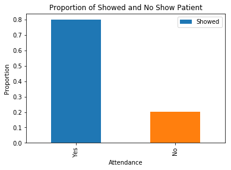

```python
# Bar chat to show the proportion of patients that Showed and didn't show for Medical appointment in Dataset
def Proportion(x,y,z,a):
    df[x].value_counts(normalize=True).plot(kind='bar');
    plt.xlabel(y)
    plt.ylabel(z)
    plt.title(a);
    plt.legend();
Proportion('Showed','Attendance','Proportion','Proportion of Showed and No Show Patient')
```

> The chart above shows that about 79.8% of the total patient showed up for their appointment while a least 20.2% didn't show up for their appointment. This proportion is needs to be criticaly investigated to know how other variables, such as (hypertension,diabetes,handicap e.t.c) affect people showing up or not and also relating patients who showed with these variables.

### 2.): Which Age Category has the highest number of patients among the patient that showed up and those that didn't show up for the appointment?

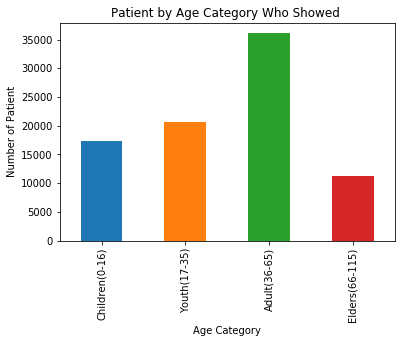

```python
# This is to create a Datafame to allow the plotting of different age group of patients that showed up for thier appointment
df1 = df.query('Num_Showed == 1')
df1 = df1.groupby('Age_Cat')['Num_Showed'].count()
df1.reset_index()
pd.DataFrame(df1)


# A function is been defined for the plotting.
def plot_bar(a,b,c,d,e,f):
      a.plot.bar(x=b, y=c);
      plt.xlabel(d)
      plt.ylabel(e)
      plt.title(f)

plot_bar(df1,'Age_Cat','Num_Showed','Age Category','Number of Patient','Patient by Age Category Who Showed ')
```

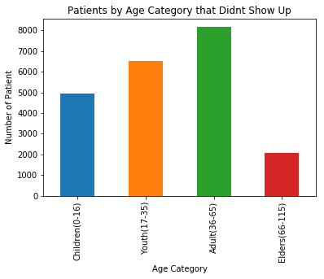

```python
# This is to create a Datafame to allow the plotting of different age group of patients that didnt showed up for thier appointment
df1 = df.query('Num_Showed == 0')
df1 = df1.groupby('Age_Cat')['Num_Showed'].count()
df1.reset_index()
pd.DataFrame(df1)


plot_bar(df1,'Age_Cat','Num_Showed','Age Category','Number of Patient','Patients by Age Category that Didnt Show Up')
```

Here we are going to investigate the Age category in relation to patient who did not show up for their appointment. This plot help to see that the **highest** value of people who didnt show up to be **over 8000** and this value is associated with **Adult** followed by **Youth** with a value of **over 6000** then Children with a value of **5000** and the **least** which is **Elder** with a value of less than **3000** patient.

### 3.): What is the Age relationship between the patient that showed and those that didn't show up?

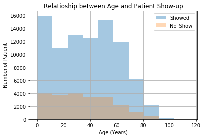

```python
# masking rows where the patient Showed and where they didn't show in the Num_Showed column
Show = df.Num_Showed ==True
No_Show = df.Num_Showed ==False

#Here we are going to plot an histogram that will show the relationship between Age patient who showed and Age of patient who didn't show.
df.Age[Show].hist(alpha = 0.4,label='Showed')
df.Age[No_Show].hist(alpha = 0.3, label= 'No_Show');
plt.xlabel('Age (Years)')
plt.ylabel('Number of Patient')
plt.title('Relatioship between Age and Patient Show-up');
plt.legend();
```

From the visual above it can be deduce that **16,000** patients between the age range of **0 - 10** Showed up, which is the **highest** number of patient that showed up. While patient between the age of **80 - 105** has the **lowest** number of patients who Showed up for their appointment. On the other hand **4000** Patients within the age of **0 - 40** didnt show up and this is the **highest** number of patient while patient above the age of 80 has the **lowest** number of patients that didnt show up.

### 4.): What is the gender distribution of all patient in the dataset?

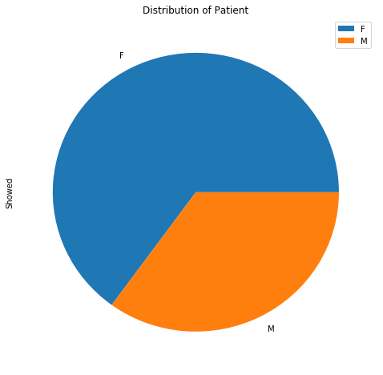

```python
# This is a function to show the sex disturbution of the Patients in the dataset.
def pie_chart(a,b,c):
    Gender = df.groupby(a)['Showed'].count()
    Gender.plot(kind='pie', y=b, legend=True, title=c,figsize=(8,8))
pie_chart('Gender','Gender','Distribution of Patient')
```

The above chart is to examine the gender distribution of the whole patients the booked an appointment to see the doctor. This chart reveals that **majority** of the patient registered for doctors appointment are **female**

### 5.): Which ailment record has the highest number of patient Showed up and the lowest number of patients Show up?

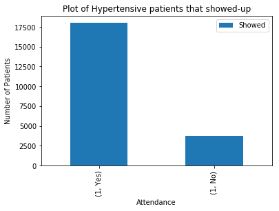

```python
# creating a dataframe to investigate patient who showed to be hypertensive and not hypertensive
df1 = df[df['Hypertension']==1]
df1 = df1.groupby('Hypertension')['Showed'].value_counts()
df1= pd.DataFrame(df1)
# creating function for the plot
def bar_plot(a,x,y,z):
    a.plot.bar();
    plt.xlabel(x)
    plt.ylabel(y)
    plt.title(z)
bar_plot(df1,'Showed', 'Number of Patients','Plot of Hypertensive patients that showed-up')
```

Among the patient who showed over 18,000 patient diagnosed and recorded to be hypertensive while over 3700 patients who are hypertensive did not show for their appointment

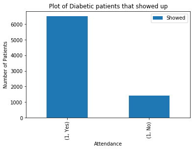

```python
# creating a dataframe to investigate patient who showed and are Diabetic and non-diabetic
df2 = df[df['Diabetes']==1]
df2 = df2.groupby('Diabetes')['Showed'].value_counts()
df2= pd.DataFrame(df2)
# recalling the plot function
bar_plot(df2,'Showed','Number of Patients','Plot of Diabetic patients that showed up')
```

Among the patient that showed up for appointment over 6000 patients were recorded to be diabetic while less than 2000 are diabetic but did not Show up

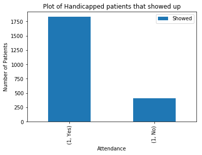

```python
# creating a dataframe to investigate patient who showed to be handicapped and not handicapped
df3 = df[df['Handicap']==1]
df3 = df3.groupby('Handicap')['Showed'].value_counts()
df3= pd.DataFrame(df3)
# recalling the plot function
bar_plot(df3,'Showed','Number of Patients','Plot of Handicapped patients that showed up')
```

Among the patient who showed up for appointment over 1750 patients were recorded to be Handicapped while less than 500 handicapped didnt show.

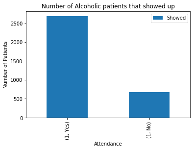

```python
# creating a dataframe to investigate patient who showed to be Alcoholic and not Alcoholic
df4 = df[df['Alcoholism']==1]
df4 = df4.groupby('Alcoholism')['Showed'].value_counts()
df4 = pd.DataFrame(df4)
# recalling the plot function
bar_plot(df4,'Showed','Number of Patients','Number of Alcoholic patients that showed up')
```

Here, Over 2500 patients who showed up for appoinment were diagnosed and recorded to be Alcoholic while less than 1000 patients were also Alcoholic but didnt show up.

Haven gone through all the plots for all the patients that showed up with different ailment, it was observed that patient who are Hypertensive has the **highest** number of patients who showed up with **over 17500** patients and patients who are Handicapped has the lowest number of patients who showed with **over 1750** patients who showed up for their appointment. Also, among those who have aliment but didnt show up Handicapped has the **lowest** number patients who has ailment and didnt show up while Hypertensive patient has the **highest** number of patients with ailment and didnt show up.

### 6.): What age group has the Highest and lowest number of patient that showed and did not show?

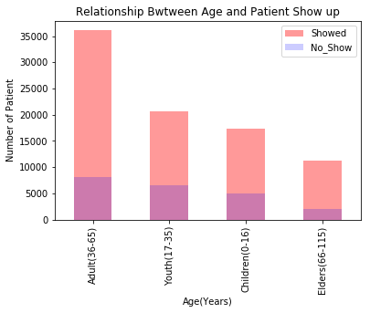

```python
# masking rows where the patient Showed and where they didn't show in the Num_Showed column
Showed = df.Num_Showed ==True
No_Show = df.Num_Showed == False
# plotting of bar chat for both patients who showed and didn't show in the Age_Category Column
df.Age_Cat[Showed].value_counts().plot(kind='bar',alpha = 0.4,color="red",label='Showed')
df.Age_Cat[No_Show].value_counts().plot(kind='bar',alpha = 0.2,color="blue", label= 'No_Show')
plt.xlabel('Age(Years)')
plt.ylabel('Number of Patient')
plt.title('Relationship Bwtween Age and Patient Show up')
plt.legend();
```

Here is a plot of patients who are categorised by age, this bar chart has the combimation of both the patients that showed for the doctors appointment and those who didn't. For the **Adult** category have the hightest number of patients who showed with over **35,000** patients in that category showed up. For this same category considering those who didnt show up, adult has over **5000** patients who didnt show up. Also, from the chart the **Elders** has the least number of patient recorded to have showed up, with a figure of over **10,000** patients, relating this to the no show plot this category still has the least number of patients who didn't show up for their appointment with value less than **5,000**. Using this bar chart above it's obvious that the **Elders Category** is much associated with the least value while **Adult Category** has the highest value. Therefore it will be required to show the general Age category distribution of all patient in the dataset.

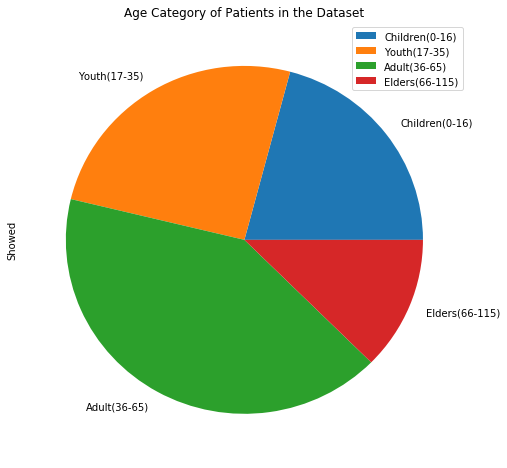

```python
# Plotting of age distribtion of all recorded patient age distribution
pie_chart('Age_Cat','Age_Cat','Age Category of Patients in the Dataset')
```

Using the pie chart it can be seen that the **Elder** Category has the least proportion in the distribution while the **Adult** has the Largest proportion in the distribution which is reponsible for lower value and higher value respectively.

### 7.): How does Date difference affect patient from Showing up for their appointment?

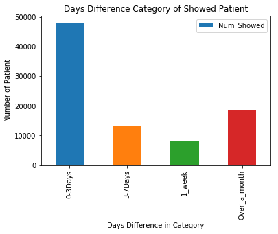

```python
# creating data frame for Date difference for those the showed
df2 = df.query('Num_Showed == 1')
df2 = df2.groupby('Date_diff_Cat')['Num_Showed'].count()
df2.reset_index()
pd.DataFrame(df1)
#recall function plot_bar
plot_bar(df2,'Date_diff_Cat','Num_Showed','Days Difference in Category','Number of Patient','Days Difference Category of Showed Patient')
plt.legend();
```

Here is a bar chart showing the representation of different **Days difference category** for patients that showed up for their appointment. It was observed that **0-3 day** has the highest number of patient that showed up which about **50,000**patients,this means this number showed up within 0 to 3 days of scheduled day to days of appointment. While Date difference of **1 week** has the lowest number of patient that showed. This shows that more people showed up with a short period from the scheduled day to the appointment day.

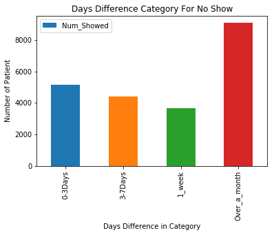

```python
# creating data frame for Date difference for those that didnt showed
df2 = df.query('Num_Showed == 0')
df2 = df2.groupby('Date_diff_Cat')['Num_Showed'].count()
df2.reset_index()
pd.DataFrame(df1)
#recall function plot_bar
plot_bar(df2,'Date_diff_Cat','Num_Showed','Days Difference in Category','Number of Patient','Days Difference Category For No Show')
plt.legend();
```

### 8.): What effect does SMS recieved by patients have on showing up or not showing up for thier appointment?

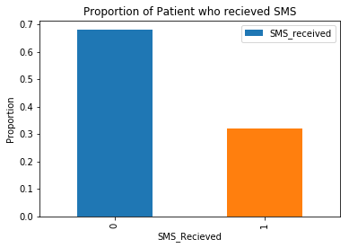

```python
# this is to show the the Proportion of those who recieved SMS and those who didnt recieve sms
Proportion('SMS_received','SMS_Recieved','Proportion','Proportion of Patient who recieved SMS')
```

This chart is to show the distribution of those who **recieved SMS (1)** and those who **did not recieve (0)** of all the Patients in the dataset. This chart shows that **higher** population of the patients **didnt recieve SMS**. Due to this observation it will be necessary to know the number of patients who didnt recieve SMS but still showed for their appointment or the number of patients who recieved SMS and didnt show.

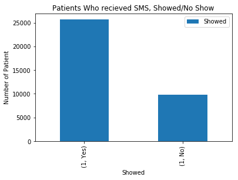

```python
# this is to investigate patients who showed among those that recieved SMS
df6 = df[df['SMS_received']==1]
df6 = df6.groupby('SMS_received')['Showed'].value_counts()
df6 = pd.DataFrame(df6)
#recall function plot_bar
bar_plot(df6,'Showed','Number of Patient','Patients Who recieved SMS, Showed/No Show')
```

With the help of this graph we can see the proportion of patients who received SMS and showed in relation to those who recieved SMS and did not Show. Making refference to this chart it can be seen that **over 25,000** patients recieved SMS and Showed for their appointment, while **10,000** patients recieved SMS but did not Show for their appointment.

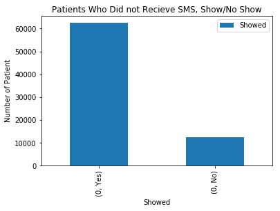

```python
# this is to investigate patients who show and didnt show among those that DIDNT recieve SMS
df7 = df[df['SMS_received']==0]
df7 = df7.groupby('SMS_received')['Showed'].value_counts()
df7 = pd.DataFrame(df7)
#recall function plot_bar
bar_plot(df7,'Showed','Number of Patient','Patients Who Did not Recieve SMS, Show/No Show')
```

Contrary to the first chart plotted to represent those who recieved SMS, this graph shows patients who did not recieve SMS but still showed for their appointment and patients who didnt recieve SMS and didnt show. Hence,the graph reveals that a larger number of the patient did not recieve SMS and still show but there is a smaller number of patients who did not recieve SMS and didnt Show. Therefore those who did recieve SMS turn out to show up more than those that recieved SMS.

## Limitation

> **1)** During these analysis it was observed that there was an error, which resulted in nagative value between the scheduled day and the appointment day. This error affected a large number of patient and among those affect majority showed up for their appointment. Therefore the rows could not be dropped instead they were assumed to be zero.

> **2** For the handicap column, it was discoverd that there are five unique value which are 0,1,2,3,4 but from the directory only two values with significance of True or False. Due to this reason values greater than 1 was assumed to be 1

```python
from subprocess import call
call(['python', '-m', 'nbconvert', 'Investigate_a_Dataset.ipynb'])
```